# A simple analysis of dataset ‘mtcars’

## **Description of dataset [mtcars](https://stat.ethz.ch/R-manual/R-devel/library/datasets/html/00Index.html)**

The dataset ‘**mtcars**’ contains 11 numeric variables with a total of 32 observations.The variables are:  
1. **mpg** - Miles/(US) gallon  
2. **cyl** - Number of cylinders  
3. **disp** - Displacement (cu.in.)  
4. **hp** - Gross horsepower  
5. **drat** - Rear axle ratio  
6. **wt** - Weight (1000 lbs)  
7. **qsec** - 1/4 mile time  
8. **vs** - Engine (0 = V-shaped, 1 = straight)  
9. **am** - Transmission (0 = automatic, 1 = manual)  
10. **gear** - Number of forward gears  
11. **carb** - Number of carburetors

## Pre-processing data

### **Checking for missing values**

```r
anyNA(mtcars)
```

```
## [1] FALSE
```

The **‘anyNA’** function is used to check if the dataset contains any missing values. As the ouput of the function is **FALSE**, it indicates all non-missing values in the dataset.

## Pre-processing data

**Checking for skewness-**  
The variables **cyl, disp, drat, wt, qsec** are normally distributed. For example, see below diagram of variables **drat** (left) and **qsec** (right).

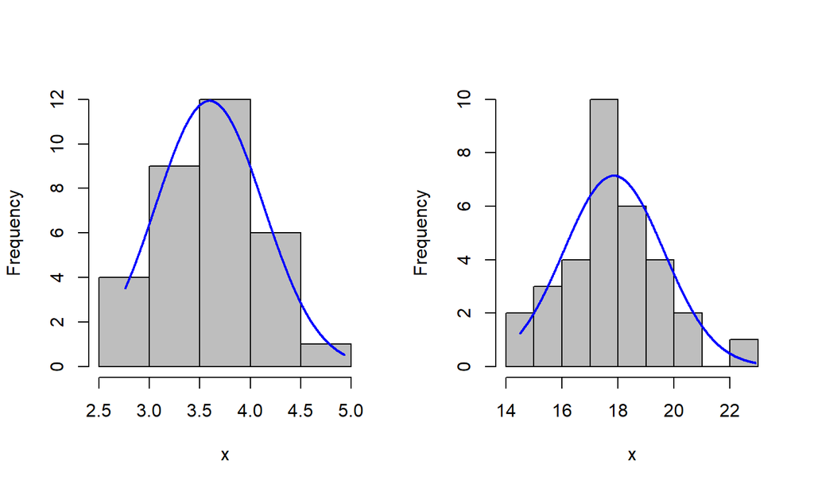

## Pre-processing data

The varibales **hp, mpg, gear** and **carb** are skewed towards the right. For example, see below diagram of varibales **hp** (left) and **mpg** (right).

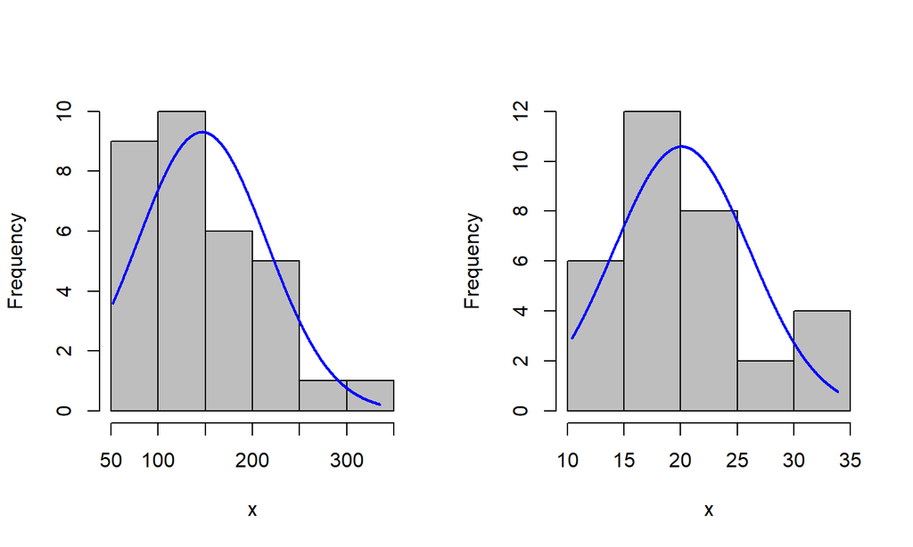

## **Scatterplots**

Variables **wt** and **mpg** (left) is negatively related as points in the graph show a downhill pattern as we move from left to right while variables **wt** and **disp** (right) are positively related to each other as the data points for x increase as y values increase.

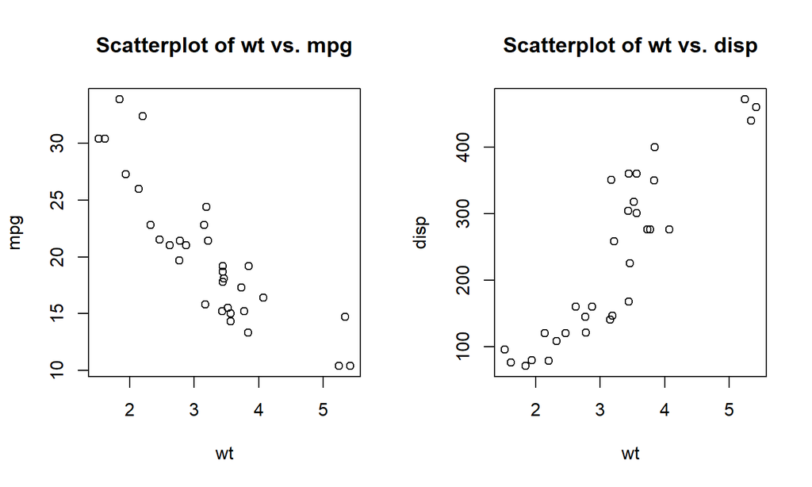

## **Linear Regression**

We use a simple linear regression function to predict miles/gallon (**mpg** - response variable) travelled from weight (**wt** - predictor variable) of the car (shown below).

```r
fit <- lm(mpg ~ wt, data=mtcars)
```

The summary of the function is presented in the next slide. We can see from the output that the model fits our data moderately well as indicated by the **Multiple R-squared value** of **0.75**. This indicates that the model accounts for **75%** of the variance in mpg (miles/gallon).  
We can also see that the **regression coefficient (-5.3)** is significantly different from zero  
(p < 0.001) and indicates that there’s an expected decrease of 5.3 units of mpg for every 1 unit increase in wt.

## Summary output of Regression model

```
##
## Call:
## lm(formula = mpg ~ wt, data = mtcars)
##
## Residuals:
##     Min      1Q  Median      3Q     Max
## -4.5432 -2.3647 -0.1252  1.4096  6.8727
##
## Coefficients:
##             Estimate Std. Error t value Pr(>|t|)
## (Intercept)  37.2851     1.8776  19.858  < 2e-16 ***
## wt           -5.3445     0.5591  -9.559 1.29e-10 ***
## ---
## Signif. codes:  0 '***' 0.001 '**' 0.01 '*' 0.05 '.' 0.1 ' ' 1
##
## Residual standard error: 3.046 on 30 degrees of freedom
## Multiple R-squared:  0.7528, Adjusted R-squared:  0.7446
## F-statistic: 91.38 on 1 and 30 DF,  p-value: 1.294e-10
```

## Regression Plot

The plot shows the regression line fitted by the model. As the data values lie around this line, this indicates that the model fits our data well.

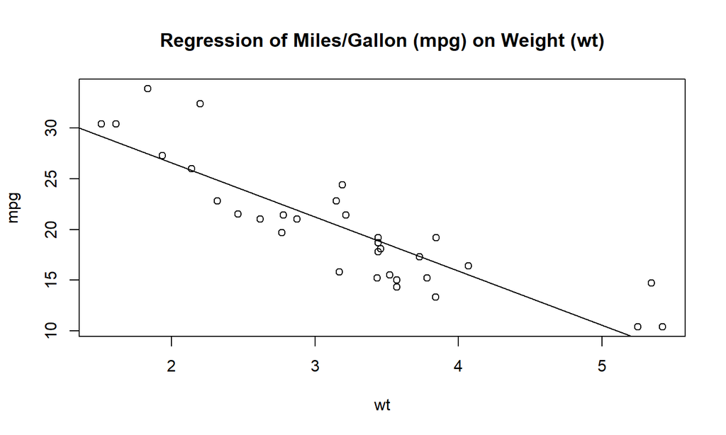